# The top down control of stability by herbivores: all work shown

Carmen Ebel

12/09/2020

# Literature Review

Understanding the mechanisms that maintain community stability is a central question in ecology. As anthropogenic drivers alter biotic and abiotic processes in ecosystems (Ripple et al. 2015), it is increasingly important to identify how this impacts stability and the strength of stabilizing mechanisms. Although there are many definitions of stability, we focus on the temporal stability of biomass production – defined as the temporal mean divided by the temporal standard deviation – as it relates to important ecosystem functions such as productivity, soil carbon storage, and forage production (Tilman 1999).

Ecosystem processes can be stabilized by a variety of biotic mechanisms, including species interactions and diversity. In particular, the roles of compensatory dynamics and species diversity have received much focus and debate (Hooper et al. 2005; Gonzalez and Loreau 2009). Compensatory dynamics stem from species in a community displaying different responses to variation in the environment. When these fluctuations in species populations are asynchronous, they stabilize the community, so although each species experiences population growth and decline, the community stays relatively constant as species trade off over time (Gonzalez and Loreau, 2009). Alternatively, when fluctuations are synchronous this enhances the variability in the community (Gonzalez and Loreau, 2009).

Diversity mediated effects on stability are likely due to the ‘portfolio effect’, where the community as a whole is less variable than its individual species due to the effects of statistical averaging (Doak et al. 1998; Tilman 1998; Schindler et al. 2015). Therefore, stability of an aggregate variable – such as biomass production – increases as diversity increases. Having a diverse assemblage of species can stabilize a community as there is a better chance that some species will maintain functioning through environmental fluctuations, even if others fail (Yachi and Loreau 1999).

Although the portfolio effect may be observed in communities with relatively even species abundances, communities with highly uneven species abundances can be disproportionately influenced by the stability of the dominant species (Doak et al. 1998). Species with high abundances tend to also have high variance (Grman et al. 2010), therefore selection for a dominant species will only stabilize the community if the species is both abundant and has a stable population over time.

As stability mechanisms are empirically tested and observed, it is becoming increasingly clear that they are context dependent (Grman et al. 2010; Hallett et al. 2014; Hautier et al. 2020). Bottom-up controls such as water or nutrient availability can influence the presence and strength of stabilizing mechanisms (Hallett et al. 2014; Hautier et al. 2020). For example, when exploring the role of precipitation in community stability, Hallett et al. found that diversity associated portfolio effects increased at sites with high mean annual precipitation, while strong negative species covariances were observed where precipitation variability was high (Hallett et al. 2014). Additionally, nutrient addition reduced compensatory dynamics and diversity compared to unfertilized communities (Hautier et al. 2020).

While there is accumulating evidence for bottom-up controls on stabilizing mechanisms, top-down control by herbivores might also influence these mechanisms, but has been relatively unexplored, especially in terrestrial systems. In lakes, the richness of zooplankton grazers indirectly impacted stability through changes in phytoplankton diversity and synchrony (Fu et al. 2020). Total grazing pressure also produced changes in synchrony as well as community dominance, which indirectly impacted stability (Fu et al. 2020). Compensatory dynamics were stabilizing in lakes with high N and high grazer richness. The portfolio effect increased stability where there was low N and high grazer richness (Fu et al. 2020).

The effects of herbivory on stability mechanisms will likely be mediated through effects on plant species diversity, evenness, and composition. In systems where herbivores consume abundant species and reduce their prevalence, plant species diversity can increase as this frees additional resources to support new species (Koerner et al. 2018, Hillebrand et al. 2007). Therefore, loss of herbivores could result in reduced plant species diversity or increased dominance by one or a few species. Indeed, previous work on the Kenya Long-term Exclosure Experiment (KLEE) has shown that excluding different groups of herbivores resulted in divergent plant communities in all treatments (Veblen et al. 2016; Riginos et al. 2018). Additionally, there was greater resistance to composition changes in treatments with cattle and wild herbivores (Riginos et al. 2018), indicating that these communities may be more stable.

**Hypothesis 1: Stability**

We hypothesize that herbivore exclusion will reduce the stability of biomass production, as communities with a diverse suite of herbivores had greater species diversity and showed greater resistance to compositional changes over the long term (Riginos et al. 2018).

**Hypothesis 2: Portfolio Effect**

As herbivory increases diversity when herbivores consume the dominant species (Koerner et al. 2018), we hypothesize that herbivore exclusion will reduce plant species diversity and therefore reduce stability.

**Hypothesis 3: Compensatory dynamics**

As compensatory and synchronous dynamics are shaped by multiple drivers at different timescales, it is possible for compensatory dynamics and synchrony to occur at different timescales within the same community (Shoemaker & Hallett, in review; Zhao et al. 2020). Therefore, we hypothesize that:

- 3a. Grazing will increase short term synchronous fluctuations in non-dominant species as it opens up space for these species to grow (Porensky et al. 2013).
- 3b. Compensatory dynamics stabilize biomass production in plots with greater grazing intensity that have high temporal variability in species composition over the short term but high resistance to compositional change long term (Riginos et al. 2018).

**Hypothesis 4: Selection for Stable Dominance**

As the relative cover of a few grass species increased dramatically when released from grazing pressure, we hypothesize that:

- 4a. This species becomes dominant when the system is released from grazing pressure and maintain the stability of total cover
- 4b. Alternatively, species that become dominant after release from grazing pressure will not be stable over time and would reduce the stability of the system.

# Methods

*Dataset Identification:*

I am using data from the Kenya Long Term Exclosure Experiment (KLEE) located on the Mpala Ranch and Conservancy property in Laikipia, Kenya. Mpala is managed for both livestock production as well as wildlife conservation. The experiment consists of six replicated herbivore exclosure treatments in a semi-arid Kenyan savanna. There are three blocks (North, Central, and South), each with six 200x200m plots for a total of 18 plots with 3 replicates of each treatment. Treatments and abbreviations are as follows: O = all herbivores excluded, W = wild meso-herbivores present (i.e. zebra, gazelles), C = cattle present, WC = cattle and wild meso-herbivores present, MW = megaherbivores (giraffes, elephants) and wild meso-herbivores present, MWC = all herbivores present. I used aerial herbaceous vegetation cover data collected bi-annually from 1999-2015 that gives the species name and the number of ‘first’ pin hits, which measures the first time a species occurred at a sampling location. This is a good measure of aerial percent cover and scales with total biomass (Veblen et al. 2016).

*Calculating Stability & Stabilizing Mechanisms*

All data exploration and analysis were carried out in R version 4.0.3. After calculating the total cover as the sum of all individual species cover in a plot, we arranged treatments in order of grazing pressure by using the total cover as an approximation for the biomass removed by herbivores (Veblen et al. 2016). We calculated stability as the temporal mean of total cover divided by the standard deviation using the community_stability() function in the codyn package (Hallett et al. 2016). We calculated the compensatory and synchronous dynamics in these communities using a variety of variance ratio and synchrony metrics. Compensatory dynamics were calculated using the time specific variance ratio (Zhao et al. 2020, Shoemaker & Hallett, in press). I used two different synchrony metrics, Loreau synchrony, which compares the variance of aggregated species abundances with the summed variances of individual species and Gross synchrony, compares the average correlation of individual species with the rest of the aggregated community (Hallett et al. 2016). Loreau synchrony is bound between 0 (perfect asynchrony) and 1 (perfect synchrony) while Gross’s synchrony is bound between -1 (perfect asynchrony) and 1 (perfect synchrony).

I calculated the Berger-Parker dominance in each community, which is a measure of the proportional biomass of the most abundant species. We looked at this over time and compared the mean dominance in each plot to stability. To verify that the portfolio effect can be used in this system, we used Taylor’s law as in Hallett et al. 2014. We found that this could not be used here. We also calculated the total richness over time and the average richness in each plot. All calculated stability mechanism metrics were compared with the calculated stability metrics. For a more detailed description of steps, please see the workflow plan below.

## Workflow

### Data QAQC

1. Working with ‘first hits’ data that is mostly processed. Species names are corrected and grouped together appropriately
2. Rename columns as R reads the numbers in and adds an X in front of them. Change to just the numbers
3. Change the data to the long format so that there is only one column with year information and one column with pin hits
4. Filter out pin hit values that are NA or 0
5. Create a unique ID for each plot as there is no unique identifying plot ID. Do this by pasting the block and treatment together
6. Create a recognizable date format using lubridate. There is only year & month information – add 01 for the day for every observation
7. Take out bare ground observations
8. This data frame can now be used in stability, variance ratio, and evenness calculations or for calculating total pin hits (cover)
9. Make a separate data frame with only treatment information by selecting each unique block, treatment, and unique ID

### Question 1: Does stability of total cover vary along a gradient of grazing intensity?

1. Sum total cover abundance in each plot
   1. Group by block, treatment, and date before taking the sum of pin hits
   2. Group by treatment and date and take the mean of the pin hits to get this data ready to visualize
   3. Group by treatment and calculate the mean total cover in each treatment and the standard error
2. Figure 1: plot the mean total cover in each treatment as points with standard error
3. Figure 2: Graph the time series of mean total cover over time with separate lines for each grazing treatment
4. Calculate community stability as: (temporal mean of total cover)/(temporal standard deviation of total cover) for each plot
   1. Use the community_stability() function from the package “codyn”
   2. Join this with the treatment data frame by unique ID
5. Calculate the CV in each plot (temporal standard deviation/temporal mean)
   1. Take the inverse of community stability metric
6. Group by treatment and calculate the mean stability and the standard error
   1. Figure 3: Graph the mean community stability as a point for each treatment with bars for standard error

### Question 2: Do stability mechanisms change with varying intensity of grazing?

**Compensatory Dynamics**

1. Calculate:
   1. Variance Ratio: variance of community as a whole compared to the sum of individual population variances
      1. Use codyn package variance_ratio() function
   2. Synchrony (Loreau): compares variance of aggregated species abundances with summed variances of individual species
      1. Use codyn package loreau_synchrony() metric to calculate this
   3. Synchrony (Gross): compare average correlation of each individual species with the rest of the aggregated community i.Use codyn package gross_synchrony metric to calculate this
   4. Timescale specific VR to detect short term synchronous dynamics (Shoemaker & Hallett in review; Zhao et al. 2020) i.Create a blank data frame with columns for the classic, long, and short variance ratios ii.Use the tsvr package tsvreq_classic() function in a for loop to calculate the three variance ratios
2. Group by treatment and calculate the mean and standard error of all metrics to use for comparison with grazing pressure and stability
3. Join both synchrony metrics into one data frame
4. Figure 4: graph the mean Loreau and Gross synchrony metrics as points with standard error bars by treatment
5. Figure 5: graph mean stability on the y-axis and mean synchrony on the x-axis. Include standard error bars in x and y directions. Color points by grazing treatment.
6. Figure 6: graph the mean time specific variance ratio for each grazing treatment. Color by variance ratio type (classic, long, and short). Add standard error bars and a line at 1 for easier comparison of compensatory vs. synchronous dynamics.

**Dominance**

**Diversity**

1. Verify portfolio effect at this site using Taylor’s law
   $$\sigma^{2} = c \mu^{z}$$
   1. Calculate temporal mean and variance for each species
   2. Take the log of each of these
   3. Plot log species variance vs. log mean abundance (should be a linear relationship)
   4. Fit a line to this log-log relationship and check the slope (the z value). This should be between 1-2 to have a stabilizing portfolio effect.
2. No further exploration as the portfolio effect is not stabilizing at this site.

## R Code

### Data QAQC

```r
## Load Packages, Read in Data ##

## set working directory
setwd("~/Repositories/klee-stability")

## Load packages
library(tidyverse)
library(lubridate)
library(codyn)
library(tsvr)
library(RColorBrewer)
library(forcats)
library(knitr)
library(bookdown)

## get google drive function
source("google-drive-function.R")

## create a function to calculate standard error
calcSE<-function(x){
  x2<-na.omit(x)
  sd(x2)/sqrt(length(x2))
}

## read in data, first hits (1999-2015), using lumped species data. Groupings determined by Kari, Lauren, & Corrina
#https://drive.google.com/file/d/10xNVrnnDDWbNBJM8nWLEm7keCMcJoXAG/view?usp=sharing
kleedat <- read_csv_gdrive("10xNVrnnDDWbNBJM8nWLEm7keCMcJoXAG") %>%
  tbl_df()
```

```r
## Data QAQC ##

## change year column names to numbers
names(kleedat) <- c("BLOCK", "TREATMENT", "SPECIES", "1999_01", "2000_02", "2000_06", "2001_01", "2001_05",
                    "2002_02", "2002_06",  "2003_02",  "2004_02",  "2004_06",  "2005_02",  "2005_06",  "2006_03",
                    "2006_06",  "2007_02", "2007_06", "2008_02", "2008_06", "2009_02", "2009_06", "2010_01",
                    "2010_06", "2011_06", "2012_06", "2013_06", "2014_06", "2015_06")


## pivot to long format so that there is a column for date (year-month combo) and for abundance
kleedat_long <- pivot_longer(kleedat, cols = "1999_01":"2015_06", names_to = "Date", values_to = "Pin_Hits")

dont_want <- c("bare") #make a vector of species that are not wanted (so far only bare ground)

## create Unique ID for each block-plot combo and format date columns so they can fit in the lubridate package
klee_long <- kleedat_long %>%
  filter(Pin_Hits > 0, !is.na(Pin_Hits)) %>% #most observations are 0
  filter(!SPECIES %in% dont_want) %>% #filter out bare ground
  mutate(Unique_ID = paste(BLOCK, TREATMENT, sep = "_")) %>% #create unique ID for each plot
  mutate(day = "01") %>% #create a filler column with day value so that dates can be parsed
  mutate(Date_junk = paste(Date, day, sep = "_")) %>% #paste filler day column with year-month column
  mutate(Date_final = ymd(Date_junk)) %>% #change dates into recognized format
  mutate(Date_numeric = paste(year(Date_final), month(Date_final), day(Date_final), sep = "0")) %>% #create column that can be coerced into numeric form
  select(BLOCK:SPECIES, Pin_Hits:Unique_ID, Date_final:Date_numeric) #select columns, drop Date and Date_junk

## change Date_numeric to integer
klee_long$Date_numeric <- as.integer(klee_long$Date_numeric)

## make a separate data frame with only treatment data. key = Unique_ID
treats <- klee_long %>%
  select(BLOCK, TREATMENT, Unique_ID) %>%
  unique()

## remove unneeded objects to keep environment clean
rm(kleedat)
rm(kleedat_long)
rm(dont_want)
```

### Question 1: R Code

#### Explore Calculated Total Cover Data (1999-2015)

```r
## Calculate Total Cover 1999-2015 ##

## group data by block, treatment, and date before summing species abundances to get total cover
klee_totcov <- klee_long %>%
  group_by(BLOCK, TREATMENT, Date_final) %>% #group by block, treatment, and date
  summarise(totcov = sum(Pin_Hits, na.rm=T)) #sum abundances to calculate tot cover
## Calculate the mean total cover for each treatment & time point
meantotcov <- klee_totcov %>%
  group_by(TREATMENT, Date_final) %>% #group by treatment & date
  summarize(Mean_TotCov = mean(totcov)) #calculate the mean total cover at each treatment & date
```

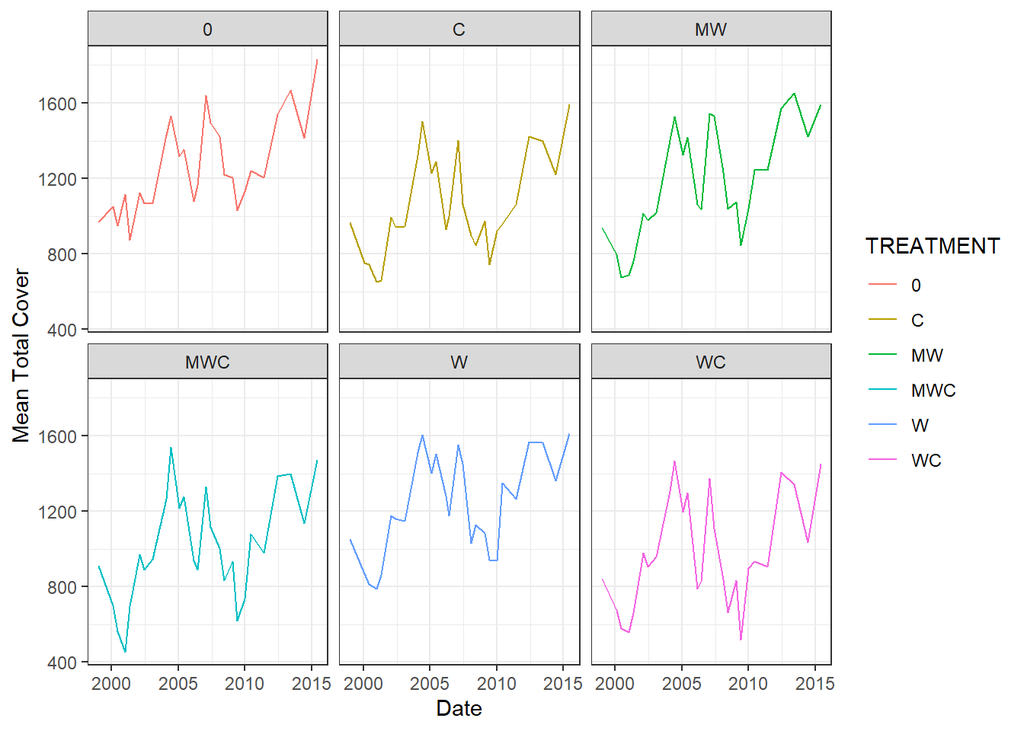

```r
## Visualize as line graph
ggplot(meantotcov, aes(x=Date_final)) +
  geom_line(aes(y=Mean_TotCov, col=TREATMENT)) + #separate by treatment to more easily view overlapping lines
  theme_bw() +
  ylab("Mean Total Cover") + xlab("Date") +
  facet_wrap(~TREATMENT)
```

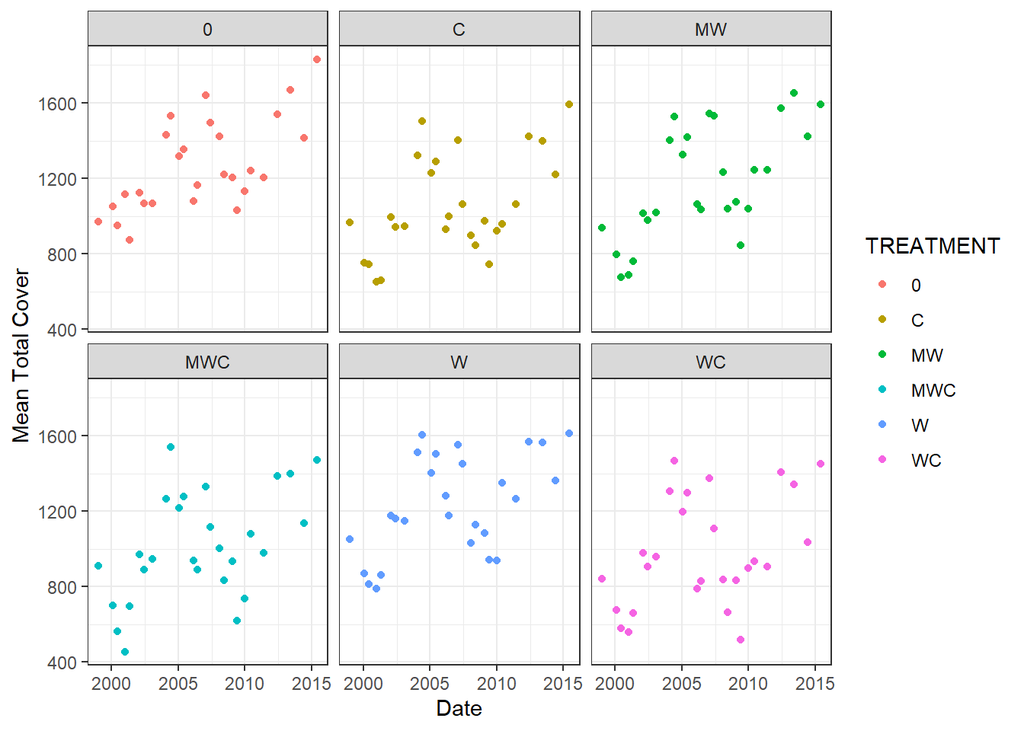

```r
## Visualize as scatterplot
ggplot(meantotcov, aes(x=Date_final, y=Mean_TotCov, col=TREATMENT)) +
  geom_point() +
  facet_wrap(~TREATMENT) +
  ylab("Mean Total Cover") + xlab("Date") +
  theme_bw()
```

```r
## Calculate mean total cover for each treatment across time
avg_biomass <- meantotcov %>%
  group_by(TREATMENT) %>% #group by treatment
  summarize(avgbio = mean(Mean_TotCov), SEbio = calcSE(Mean_TotCov)) #calculate mean and standard error of total cover
#reorder treatments to match grazing pressure.
avg_biomass$TREATMENT <- as.factor(avg_biomass$TREATMENT) #change treatment to factor
avg_biomass$TREATMENT <- factor(avg_biomass$TREATMENT, levels = c("0", "W",  "MW",  "C", "MWC", "WC"))
```

#### Calculate Stability Metrics

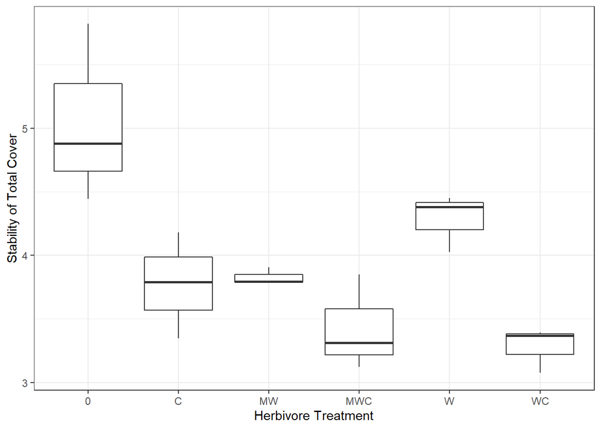

```r
## Community Stability ##

## calculate community stability metric for each plot
commstab <- community_stability(klee_long,
                                time.var = "Date_numeric",
                                abundance.var = "Pin_Hits",
                                replicate.var = "Unique_ID")

## join with treatment info & calculate CV
stability <- left_join(commstab, treats, by = "Unique_ID") %>% #join community stability with treatment info
  mutate(CV = 1/stability) #calculate the CV by taking the inverse of stability

## graph stability with treatment info (boxplot)
ggplot(stability, aes(x=TREATMENT, y=stability)) +
  geom_boxplot() +
  ylab("Stability of Total Cover") + xlab("Herbivore Treatment") +
  theme_bw()
```

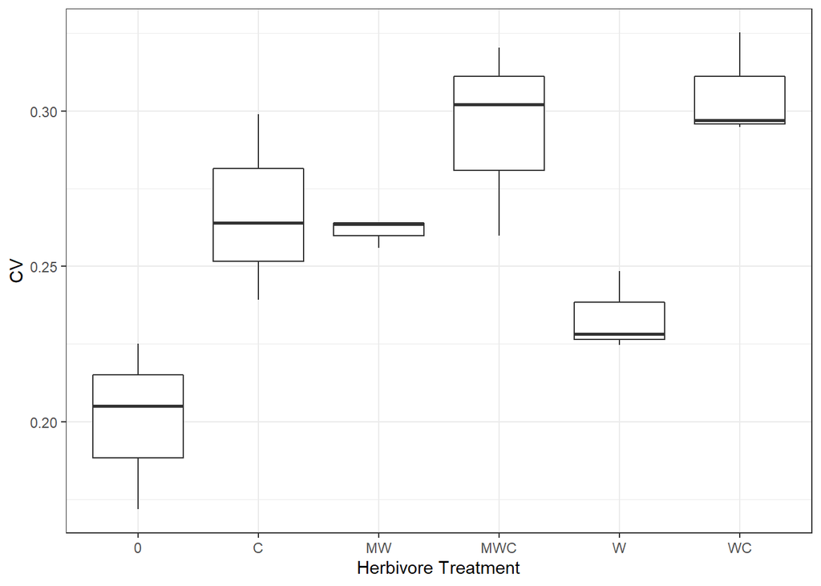

```r
## graph CV with treatment info (boxplot)
ggplot(stability, aes(x=TREATMENT, y=CV)) +
  geom_boxplot() +
  ylab("CV") + xlab("Herbivore Treatment") +
  theme_bw()
```

```r
## create a dataframe with mean & standard error of stability & CV by treatment
mean_stability <- stability %>%
  group_by(TREATMENT) %>%
  summarize(mean_st = mean(stability), SEst = calcSE(stability), mean_cv = mean(CV), SECV = calcSE(CV))
## reorder treatments to match grazing pressure.
mean_stability$TREATMENT <- as.factor(mean_stability$TREATMENT) #change treatment to factor
mean_stability$TREATMENT <- factor(mean_stability$TREATMENT, levels = c("0", "W",  "MW",  "C", "MWC", "WC"))
```

### Question 2: R Code

#### Calculate Synchrony Metrics

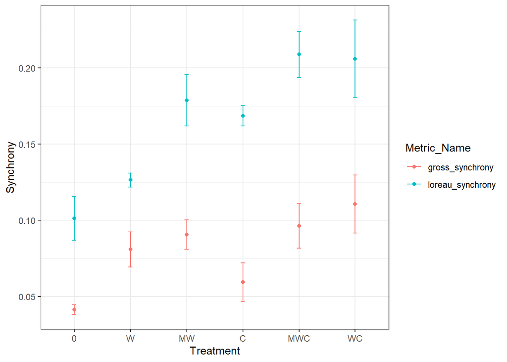

```r
## Calculate Synchrony Metrics ##

## Calculate Loreau synchrony metric
loreau_synchrony <- synchrony(
  klee_long,
  time.var = "Date_numeric",
  species.var = "SPECIES",
  abundance.var = "Pin_Hits",
  metric = "Loreau",
  replicate.var = "Unique_ID"
)
colnames(loreau_synchrony) <- c("Unique_ID", "loreau_synchrony") #rename columns

## Calculate Gross synchrony metric
gross_synchrony <- synchrony(
  klee_long,
  time.var = "Date_numeric",
  species.var = "SPECIES",
  abundance.var = "Pin_Hits",
  replicate.var = "Unique_ID",
  metric="Gross")
colnames(gross_synchrony) <- c("Unique_ID", "gross_synchrony") #rename columns

## join two synchrony metrics into one data frame
synchrony <- left_join(loreau_synchrony, gross_synchrony, by = "Unique_ID")

## calculate mean & SE of metrics to get ready for graphing
mean_synchrony <- left_join(synchrony, treats, by = "Unique_ID") %>%
  pivot_longer(cols = loreau_synchrony:gross_synchrony, names_to = "Metric_Name", values_to = "Synchrony") %>% #pivot to long format
  group_by(TREATMENT, Metric_Name) %>%
  summarise(mean_value = mean(Synchrony), SE_value = calcSE(Synchrony))
## reorder treatments to match grazing pressure.
mean_synchrony$TREATMENT <- as.factor(mean_synchrony$TREATMENT) #change treatment to factor
mean_synchrony$TREATMENT <- factor(mean_synchrony$TREATMENT, levels = c("0", "W",  "MW",  "C", "MWC", "WC"))

## join synchrony & stability data frames to get ready for graphing
syn_stab <- inner_join(mean_synchrony, mean_stability, by = "TREATMENT")

## visualize synchrony metrics together
ggplot(mean_synchrony, aes(x=TREATMENT, y=mean_value, col = Metric_Name)) +
  geom_point() +
  geom_errorbar(aes(ymin = mean_value-SE_value, ymax = mean_value+SE_value), width= 0.075) +
  ylab("Synchrony") + xlab("Treatment") +
  theme_bw()
```

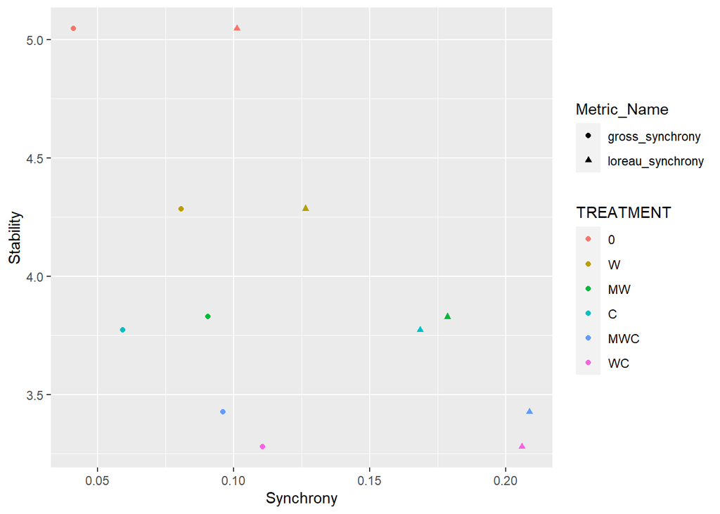

```r
## Visualize synchrony & stability metrics
ggplot(syn_stab, aes(x=mean_value , y=mean_st, col = TREATMENT, shape = Metric_Name)) +
  geom_point() +
  ylab("Stability") + xlab("Synchrony")
```

#### Calculate Time Specific Variance Ratio

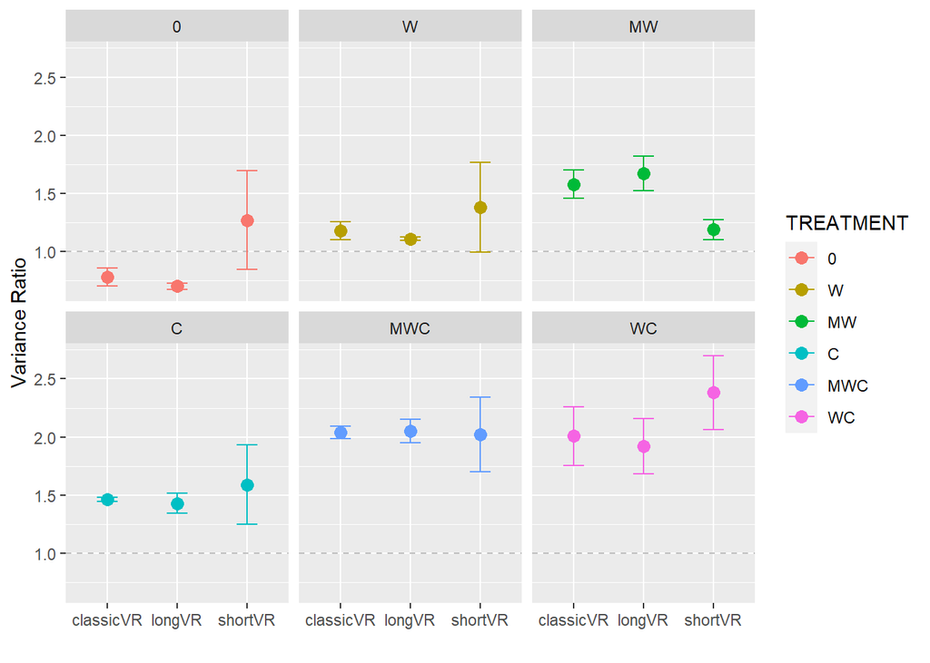

```r
## Calculate Timescale Specific VR ##

#set up data frame to put tsvr into
outnames <- c("Unique_ID", "TREATMENT", "classicVR", "longVR", "shortVR") #column names
siteout <- as.data.frame(matrix(nrow=0, ncol = 5)) #make empty dataframe
names(siteout) <- outnames #set names for empty dataframe
plots <- unique(klee_long$Unique_ID) #make vector of unique plots

## Use for loop to calculate TSVR for each plot
for (i in 1:length(plots)) {

  #subset by replicate (gives all observations from one plot over time)
  plot <- subset(klee_long, Unique_ID == plots[i]) %>%
    tbl_df()

  #select species and fill 0's
  plot2 <- plot %>%
    select(Date_numeric, SPECIES, Pin_Hits) %>% #selecting only these three columns
    spread(SPECIES, Pin_Hits, fill = 0) #changing to wide format

  #transpose the data
  dat <- t(as.matrix(plot2[,2:dim(plot2)[2]]))

  #create a dataframe with replicate info to attach VR metrics to
  VR_plots <- plot %>%
    select(Unique_ID, TREATMENT, BLOCK) %>%
    unique()

  #calculate classic VR
  res0 <- vreq_classic(dat)
  VR_plots$classicVR <- res0[[3]]

  #calculate tsvr
  res <- tsvreq_classic(dat)

  #aggregate short vs. long variance ratios
  resLong <- aggts(res, res$ts[res$ts>=4]) #grabbing tsvr with time period >= 4 years
  resShort <- aggts(res, res$ts[res$ts<4]) #grabbing tsvr with time period <4 years

  #attach short & long variance ratios
  VR_plots$longVR <- resLong[[3]]
  VR_plots$shortVR <- resShort[[3]]

  #append to external dataframe
  siteout<-rbind(siteout, VR_plots)
}

#rename data frame
tsVR <- siteout


## Calculate the mean and standard error of VR metrics
meantsVR <- tsVR %>%
  pivot_longer(cols = classicVR:shortVR, names_to = "VR_type", values_to = "VR_value" ) %>% #change to long format
  group_by(TREATMENT, VR_type) %>%
  summarise(meanVR = mean(VR_value), SEVR = calcSE(VR_value))
#reorder treatments to match grazing pressure.
meantsVR$TREATMENT <- as.factor(meantsVR$TREATMENT) #change treatment to factor
meantsVR$TREATMENT <- factor(meantsVR$TREATMENT, levels = c("0", "W",  "MW",  "C", "MWC", "WC"))


## Visualize time specific variance ratio
#VR by VR type, faceted by treatment
ggplot(meantsVR, aes(x=VR_type, y=meanVR, col = TREATMENT)) +
  geom_hline(yintercept = 1, color = "grey", lty = "dashed") +
  geom_point(size = 3) +
  geom_errorbar(aes(ymin = meanVR-SEVR, ymax = meanVR+SEVR), width = 0.3) +
  facet_wrap(~TREATMENT) +
  ylab("Variance Ratio") + xlab("")
```

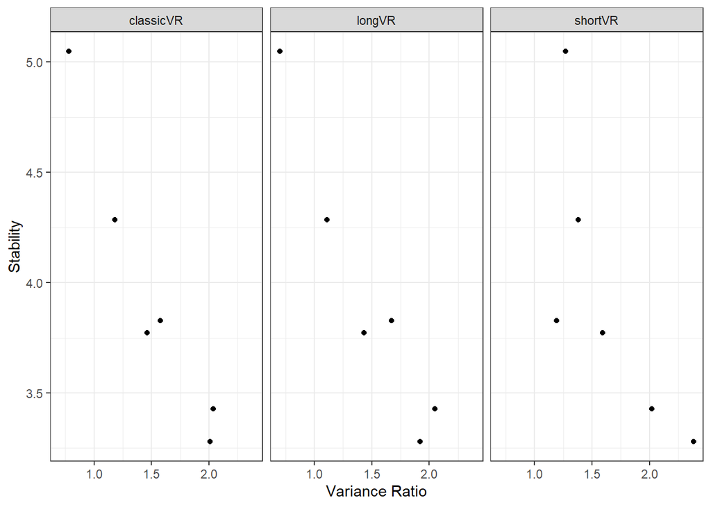

```r
## Compare VR & Stability ##

## join mean stability & mean tsVR data frames.
tsvr_stab <- inner_join(mean_stability, meantsVR, by = "TREATMENT")

#plot stability vs. VR to see if they are correlated.
ggplot(tsvr_stab, aes(x=meanVR, y=mean_st)) +
  geom_point() +
  facet_wrap(~VR_type) +
  ylab("Stability") + xlab("Variance Ratio") +
  theme_bw()
```

```r
## Create a data frame with all synchrony and variance ratio metrics in order to make a table.
## change mean synchrony to wide format
meansyn <- mean_synchrony %>%
  pivot_wider(names_from = "Metric_Name", values_from = "mean_value") %>% #make unique columns for each synchrony metric
  group_by(TREATMENT) %>%
  summarise(GS=mean(gross_synchrony, na.rm = T), LS=mean(loreau_synchrony, na.rm = T)) #calculate the mean for each treatment and remove NAs to get rid of the weird column format that pivot wider creates here
## change mean tsvr to wide format
tsvrmean <- tsvr_stab %>%
  pivot_wider(names_from = "VR_type", values_from = "meanVR") %>% #make unique column for each variance ratio metric
  group_by(TREATMENT) %>%
  summarise(classic=mean(classicVR, na.rm = TRUE), short = mean(shortVR, na.rm=TRUE), long=mean(longVR, na.rm = TRUE)) #calculate the mean for each treatment and remove NAs to get rid of the weird column format that pivot wider creates here
## join synchrony and variance ratio data frames
comp_dyn <- left_join(meansyn, tsvrmean, by = "TREATMENT")
```

#### Calculate Dominance

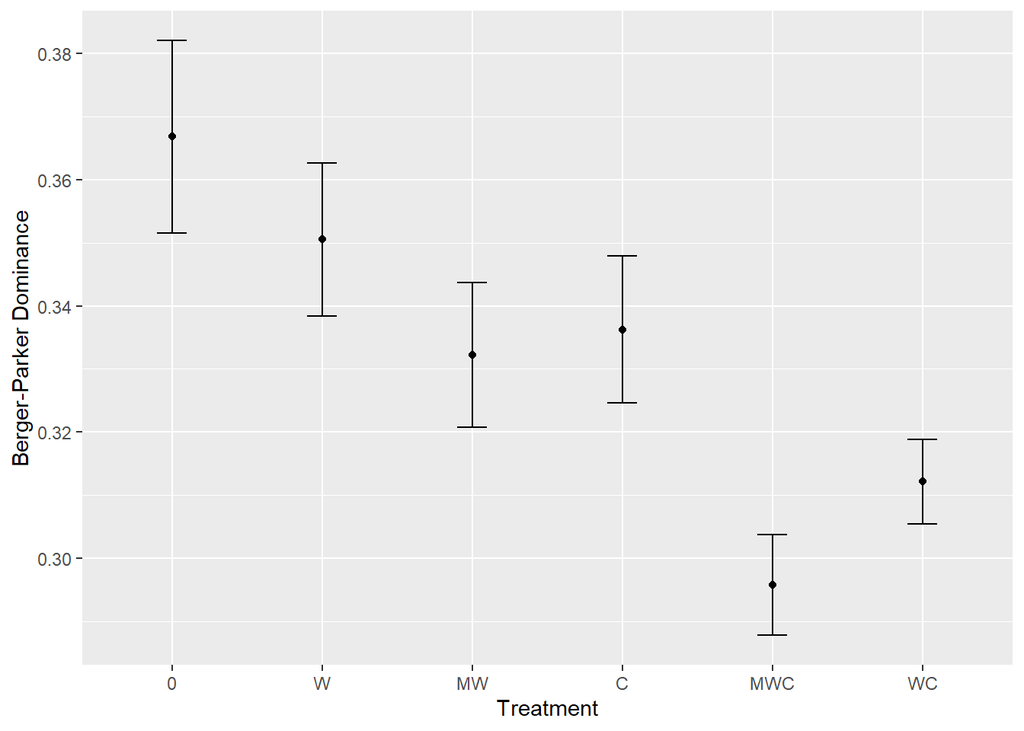

```r
## Calculate Berger-Parker Dominance ##
#BP dominance: d = Nmax/N (relative abundance of most dominant species)
BP_dom <- klee_long %>%
  group_by(TREATMENT, Unique_ID, Date_final) %>% #group by treatment, plot, and date
  mutate(rank = rank(Pin_Hits, na.last = NA, ties.method = "average")) %>% #rank species in order of abundance
  mutate(tot_abund = sum(Pin_Hits)) %>% #calculate total abundance
  filter(rank == max(rank)) %>% #only include most abundant species in each plot
  summarise(BP_dominance = Pin_Hits/tot_abund) %>% #calculate Berger-Parker dominance index
  group_by(TREATMENT, Date_final) %>% #group by treatment and date
  summarise(mean_dom = mean(BP_dominance), SEdom = calcSE(BP_dominance)) #calculate mean and SE for each treatment at each date
#reorder treatments to match grazing pressure.
BP_dom$TREATMENT <- as.factor(BP_dom$TREATMENT) #change treatment to factor
BP_dom$TREATMENT <- factor(BP_dom$TREATMENT, levels = c("0", "W",  "MW",  "C", "MWC", "WC"))

## calculate the mean dominance index by treatment
avg_BPdom <- BP_dom %>%
  group_by(TREATMENT) %>% #group by treatment
  summarise(avg_dom = mean(mean_dom), SE = calcSE(mean_dom)) #take mean across time for each treatment
#reorder treatments to match grazing pressure.
avg_BPdom$TREATMENT <- as.factor(avg_BPdom$TREATMENT) #change treatment to factor
avg_BPdom$TREATMENT <- factor(avg_BPdom$TREATMENT, levels = c("0", "W",  "MW",  "C", "MWC", "WC"))

## join stability & dominance data frames
dom_stab <- inner_join(mean_stability, avg_BPdom, by = "TREATMENT")

## visualize mean dominance by grazing treatment
ggplot(avg_BPdom, aes(x=TREATMENT, y=avg_dom)) +
  geom_point() +
  ylab("Berger-Parker Dominance") + xlab("Treatment") +
  geom_errorbar(aes(ymin=avg_dom-SE, ymax=avg_dom+SE), width=0.2)
```

#### Verifying the Portfolio Effect

```r
## Verify Portfolio Effect ##

## group by unique ID and species to calculate the mean and variance of each species
portfolio_effect <- klee_long %>%
  filter(!is.na(SPECIES), !is.na(Pin_Hits)) %>% #filter out any NA values
  filter(Pin_Hits > 0) %>% #filter out abundances of 0
  group_by(Unique_ID, SPECIES) %>% #group by unique_ID & species
  summarise(variance = var(Pin_Hits, na.rm = TRUE), meanhits = mean(Pin_Hits)) %>% #calculate mean & variance
  mutate(logvar = log(variance), logmean = log(meanhits)) #log transform mean and variance
## remove log values less than 0
#linear model doesn't seem to work with NA and 0 values
portfolio <- portfolio_effect %>%
  filter(logvar > 0, logmean > 0)

#run a linear model to calculate the slope
taylor <- lm(logmean~logvar, data = portfolio)
summary(taylor)
```

```
##
## Call:
## lm(formula = logmean ~ logvar, data = portfolio)
##
## Residuals:
##      Min       1Q   Median       3Q      Max
## -0.91818 -0.24530 -0.00812  0.22801  1.38217
##
## Coefficients:
##             Estimate Std. Error t value Pr(>|t|)
## (Intercept) 0.360386   0.024793   14.54   <2e-16 ***
## logvar      0.486023   0.005239   92.77   <2e-16 ***
## ---
## Signif. codes:  0 '***' 0.001 '**' 0.01 '*' 0.05 '.' 0.1 ' ' 1
##
## Residual standard error: 0.3592 on 711 degrees of freedom
## Multiple R-squared:  0.9237, Adjusted R-squared:  0.9236
## F-statistic:  8607 on 1 and 711 DF,  p-value: < 2.2e-16
```

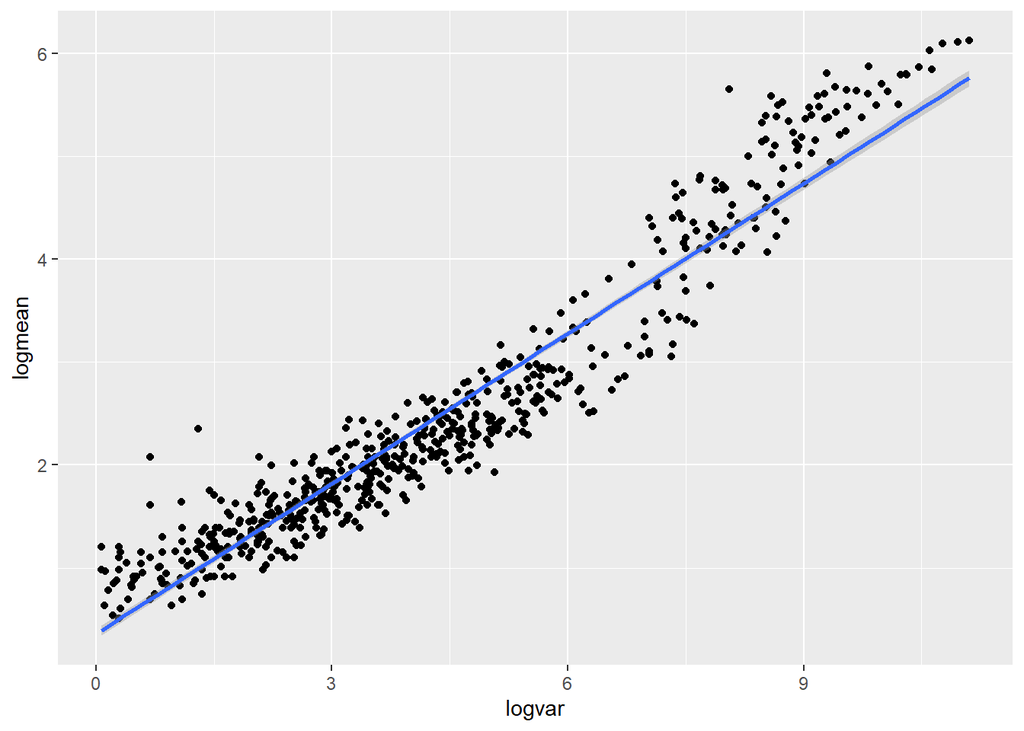

```r
#check that slope is between 1-2
## slope is 0.486023

## plot log variance and log mean
ggplot(portfolio, aes(x=logvar, y=logmean)) +
  geom_point() +
  geom_smooth(method = "lm")
```

#### Make graphics adjustments

```r
green_scale <- c("#97e196", "#6cc08b", "#4c9b82", "#217a79", "#105965", "#074050") #make a vector of colors
theme_set(theme_bw()) #set the theme
```

# Results

We ordered treatments in order of total cover, which scales linearly with standing biomass and the amount of biomass removed by herbivores (Veblen et al. 2016). Thus, our gradient of grazing intensity was 0, W, MW, C, MWC, WC (Figure 1). Total cover varies over time and treatments appear synchronous in their fluctuations at many points (Figure 2). The stability of biomass production declined with grazing intensity, so that the most stable treatment was complete herbivore removal, and the least stable treatments were MWC and WC (Figure 3).

All treatments with herbivores had weak synchronous dynamics that generally increased along the gradient of grazing intensity (Table 1, Figure 4). Both the Loreau and Gross synchrony metrics followed the same pattern, except for the cattle treatment which had lower synchrony than W and MW treatments as measured by the Gross synchrony metric. The most synchronous treatments were MWC (GS = 0.0961179, LS = 0.2087248) and WC (GS = 0.1106211, LS = 0.2058985) (Figure 4) and complete herbivore removal had the lowest synchrony values, GS = 0.0412301 and LS = 0.1011377 (Table 1). The only treatment with a variance ratio below 1 (compensatory dynamics) was 0, or complete herbivore removal (Table 1). The classic and long variance ratios also increased along the gradient of grazing pressure (Table 1). The short- and long-term variance ratios were only different for the 0 and MW treatments as 0 had a larger short term variance ratio and MW had a smaller short term variance ratio (Figure 6, Table 1). Overall, synchrony was negatively correlated with stability (Figure 5).

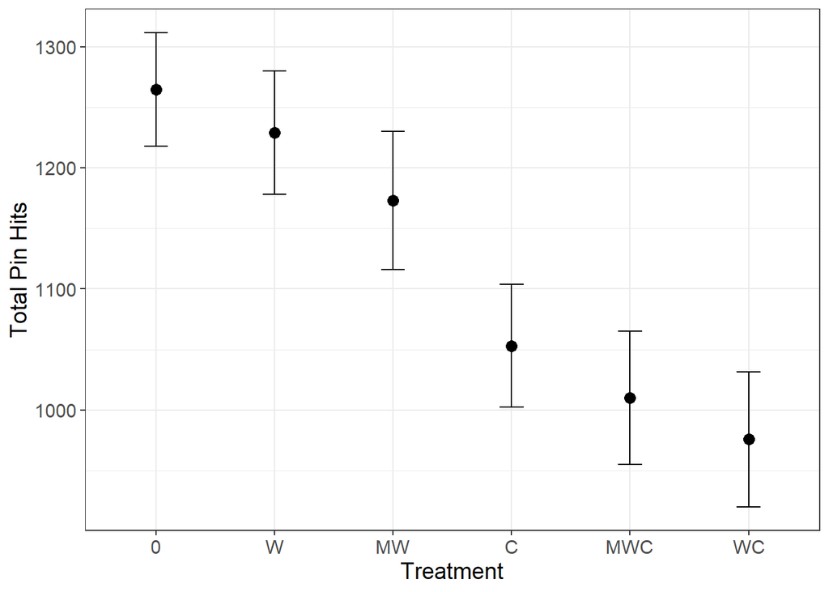

**Figure 1:** Points represent the mean total cover for each treatment, averaged across the time series. Bars are one standard error. Treatment abbreviations are as follows: 0 = No herbivores, W = Wild mesoherbivores, MW = Megaherbivores and wild mesoherbivores, C = cattle, MWC = Megaherbivores, wild mesoherbivores, and cattle, WC = Wild mesoherbivores and cattle

```r
#graph the mean total pin hits by treatment
ggplot(avg_biomass, aes(x=TREATMENT, y=avgbio)) +
  geom_point(size=3) +
  geom_errorbar(aes(ymin=avgbio-SEbio, ymax=avgbio+SEbio), width = 0.2) + #include standard error bars
  ylab("Total Pin Hits") + xlab("Treatment") + #label axes
  theme(text = element_text(size = 14)) #change font size
```

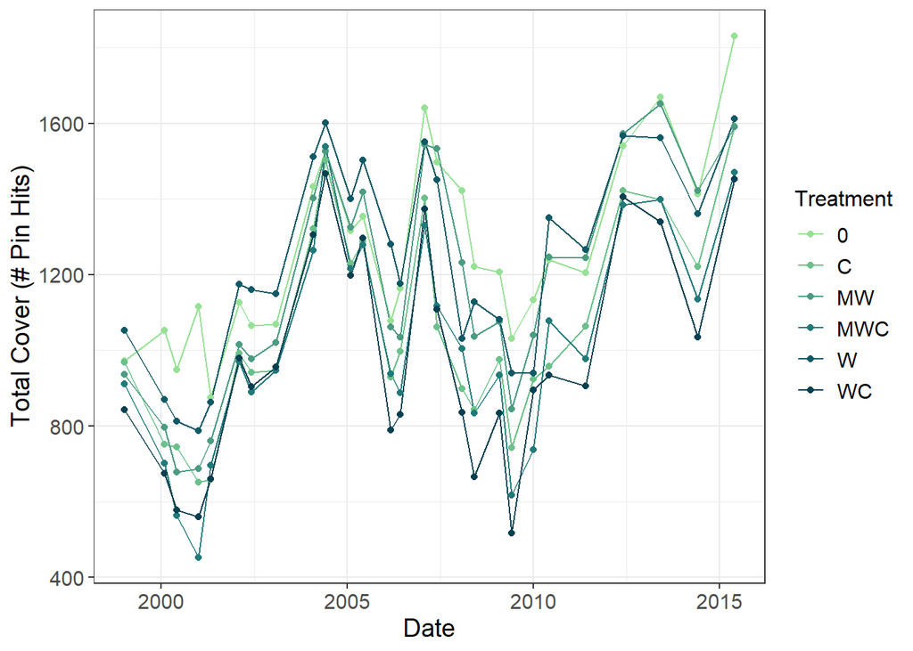

```r
#graph the time series of total cover
ggplot(meantotcov, aes(x=Date_final, y=Mean_TotCov, col=TREATMENT)) + #separate treatments by color
  geom_line(size = 0.5) +
  geom_point(aes(y=Mean_TotCov)) +
  scale_color_manual(values = green_scale) + #change color scheme
  ylab("Total Cover (# Pin Hits)") + xlab("Date") + labs(col = "Treatment") + #add labels
  theme(legend.title = element_text(size=12)) + theme(text = element_text(size = 14)) #change font sizes
```

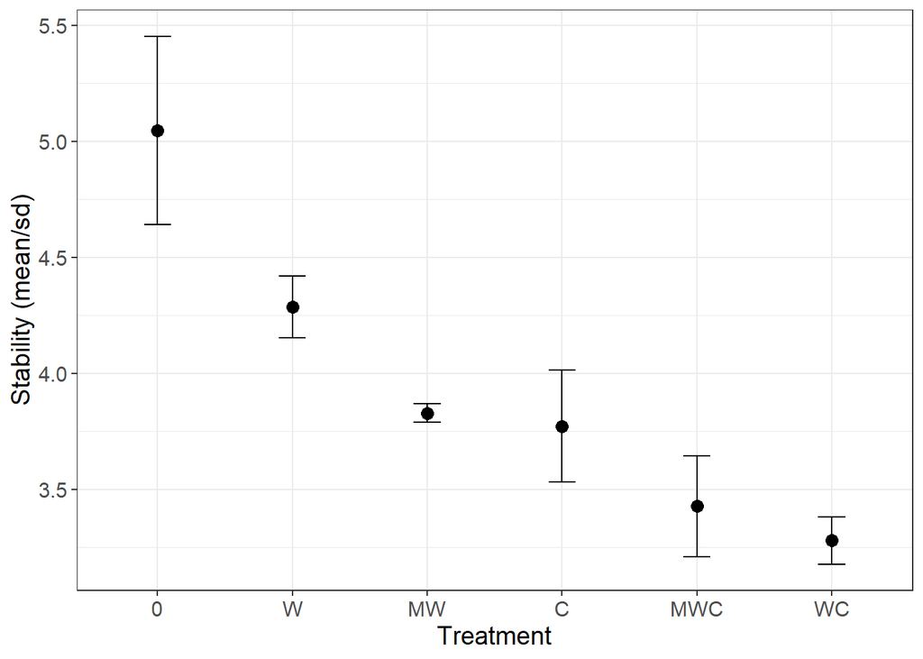

**Figure 3:** Points show the mean stability value for each grazing treatment. Bars are one standard error. Treatment abbreviations are as follows: 0 = No herbivores, W = Wild mesoherbivores, MW = Megaherbivores and wild mesoherbivores, C = cattle, MWC = Megaherbivores, wild mesoherbivores, and cattle, WC = Wild mesoherbivores and cattle

```r
## visualize mean stability & standard error
ggplot(mean_stability, aes(x=TREATMENT, y=mean_st)) +
  geom_point(size=3) +
  geom_errorbar(aes(ymin = mean_st-SEst, ymax=mean_st+SEst), width = 0.2) + #add standard error bars
  ylab("Stability (mean/sd)") + xlab("Treatment") + #label axes
  theme(text = element_text(size = 14)) #change font size
```

```r
#create a table of all synchrony and variance ratio metrics
kable(comp_dyn, col.names = c("Treatment", "Gross Synchrony", "Loreau Synchrony", "Classic Variance Ratio", "Short Variance Ratio", "Long Variance Ratio"), caption = 'Table 1: Synchrony')
```

Table 1: Synchrony

| Treatment | Gross Synchrony | Loreau Synchrony | Classic Variance Ratio | Short Variance Ratio | Long Variance Ratio |
| --- | --- | --- | --- | --- | --- |
| 0 | 0.0412301 | 0.1011377 | 0.7815846 | 1.271081 | 0.7014436 |
| W | 0.0807293 | 0.1263684 | 1.1789052 | 1.380914 | 1.1105448 |
| MW | 0.0906036 | 0.1786671 | 1.5782404 | 1.189615 | 1.6729170 |
| C | 0.0592708 | 0.1685149 | 1.4624040 | 1.590983 | 1.4310725 |
| MWC | 0.0961179 | 0.2087248 | 2.0390444 | 2.021190 | 2.0515415 |
| WC | 0.1106211 | 0.2058985 | 2.0085923 | 2.382120 | 1.9211024 |

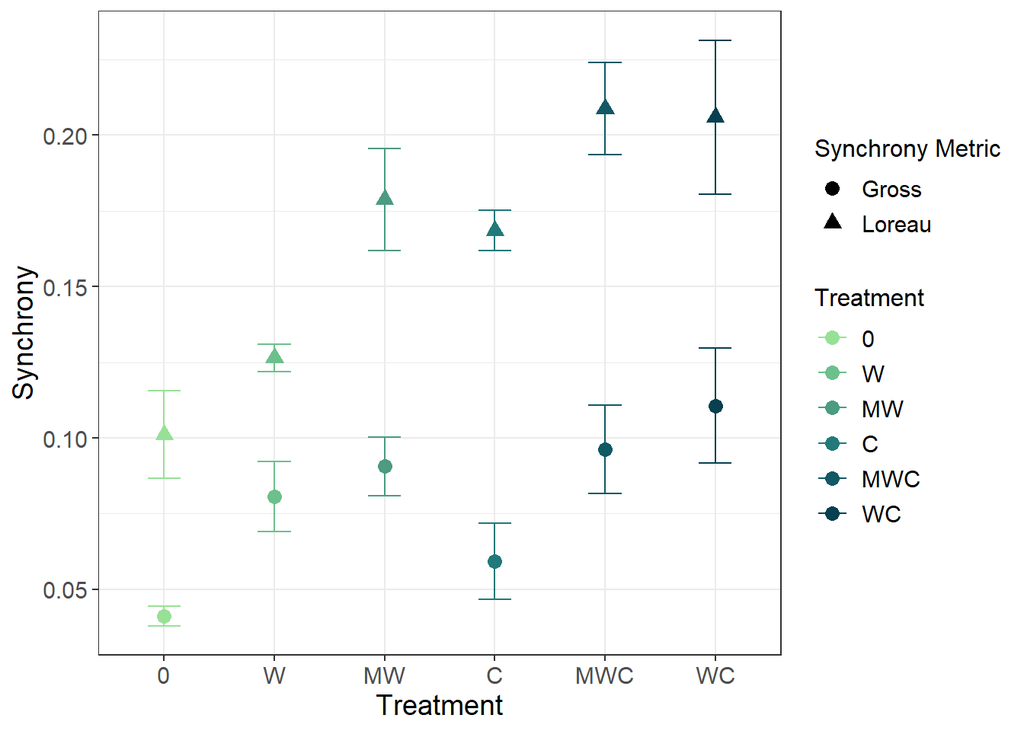

```r
### SYNCHRONY & Grazing Tx FINAL FIGURE
ggplot(syn_stab, aes(x=TREATMENT , y=mean_value, col=TREATMENT, shape = Metric_Name)) +
  geom_point(size=3) +
  scale_color_manual(values = green_scale) +
  geom_errorbar(aes(ymin = mean_value-SE_value, ymax=mean_value+SE_value), width = 0.3) +
  ylab("Synchrony") + xlab("Treatment") +
  theme(legend.title = element_text(size=12)) +  theme(text = element_text(size = 14)) + #change font sizes
  labs(col = "Treatment", shape = "Synchrony Metric") + #add legend titles
  scale_shape_discrete(labels = c("Gross", "Loreau")) #rename synchrony metrics in legend
```

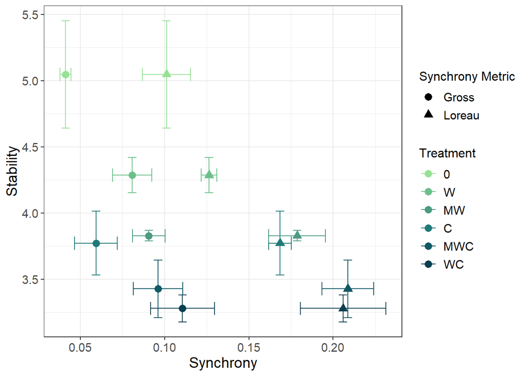

```r
### SYNCHRONY & STABILITY FINAL FIGURE
ggplot(syn_stab, aes(x=mean_value , y=mean_st, col = TREATMENT, shape=Metric_Name)) +
  geom_point(size=3) +
  scale_color_manual(values = green_scale) +
  geom_errorbar(aes(ymin=mean_st-SEst, ymax=mean_st+SEst), width = 0.005) + #add standard error bars
  geom_errorbarh(aes(xmin = mean_value-SE_value, xmax=mean_value+SE_value), height = 0.1) + #add standard error bars
  ylab("Stability") + xlab("Synchrony") +  #label axes
  theme(legend.title = element_text(size=12)) + theme(text = element_text(size = 14)) + #change font sizes
  labs(col = "Treatment", shape = "Synchrony Metric") +
  scale_shape_discrete(labels = c("Gross", "Loreau"))
```

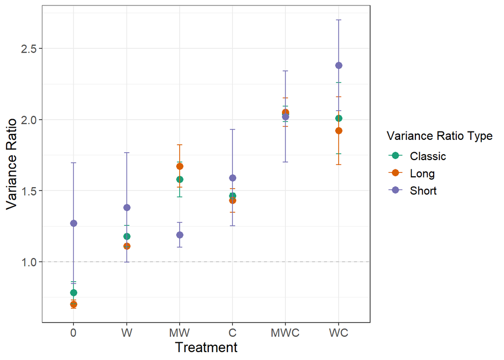

**Figure 6:** Points show the variance ratio for each grazing treatment. Color represents the variance ratio type: green is the classic variance ratio, orange is the long variance ratio (timescales > 4 years) and purple is the short variance ratio (timescales < 4 years). Bars show one standard error. Treatment abbreviations are as follows: 0 = No herbivores, W = Wild mesoherbivores, MW = Megaherbivores and wild mesoherbivores, C = cattle, MWC = Megaherbivores, wild mesoherbivores, and cattle, WC = Wild mesoherbivores and cattle

```r
### TSVR & GRAZING TREATMENT FINAL FIGURE
#variance ratio vs. treatment, grouped by VR type
ggplot(meantsVR, aes(x=TREATMENT, y=meanVR, col = VR_type)) +
  geom_hline(yintercept = 1, color = "grey", lty = "dashed") +
  geom_point(size = 3) +
  geom_errorbar(aes(ymin = meanVR-SEVR, ymax = meanVR+SEVR), width = 0.1) +
  theme_bw() +
  scale_color_brewer(palette = "Dark2", labels = c("Classic", "Long", "Short")) +
  ylab("Variance Ratio") + xlab("Treatment") +
  theme(legend.title = element_text(size=12)) +
  theme(text = element_text(size = 14)) +
  labs(col = "Variance Ratio Type") #change legend title
```

[output not shown]

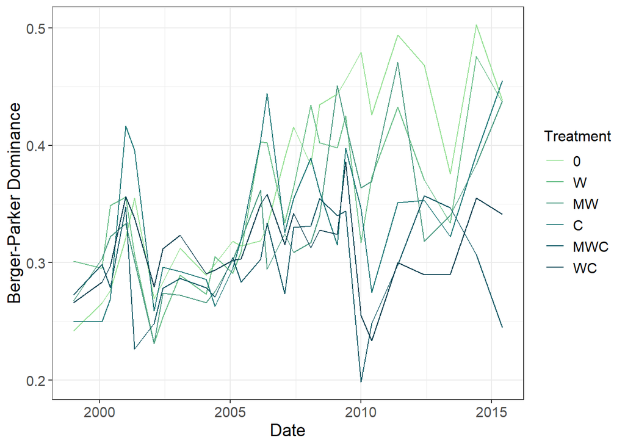

**Figure 7:** Lines show the mean Berger-Parker dominance across time for each grazing treatment. Treatment abbreviations are as follows: 0 = No herbivores, W = Wild mesoherbivores, MW = Megaherbivores and wild mesoherbivores, C = cattle, MWC = Megaherbivores, wild mesoherbivores, and cattle, WC = Wild mesoherbivores and cattle

```r
## Graph dominance over time
ggplot(BP_dom, aes(x=Date_final, y=mean_dom, col=TREATMENT)) +
  geom_line(size = 0.5) +
  theme_bw() +
  scale_color_brewer(palette = "Dark2") +
  ylab("Berger-Parker Dominance") + xlab("Date") +
  scale_color_manual(values = green_scale) +
  theme(legend.title = element_text(size=12)) +
  theme(text = element_text(size = 14)) +
  labs(col = "Treatment") #change legend title
```

[output not shown]

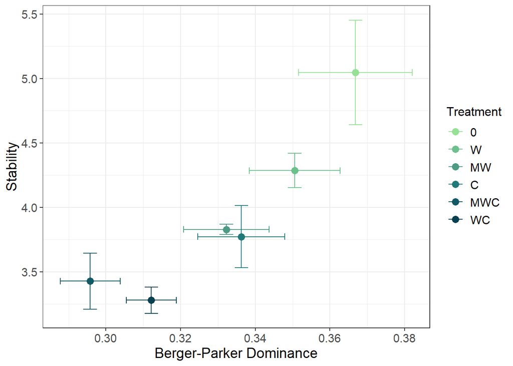

**Figure 8:** Points represent the mean stability and mean Berger-Parker dominance for each grazing treatment. Points are colored according to grazing treatment. Bars show one standard error. Treatment abbreviations are as follows: 0 = No herbivores, W = Wild mesoherbivores, MW = Megaherbivores and wild mesoherbivores, C = cattle, MWC = Megaherbivores, wild mesoherbivores, and cattle, WC = Wild mesoherbivores and cattle

```r
## Graph dominance and stability
ggplot(dom_stab, aes(x=avg_dom, y=mean_st, col=TREATMENT)) +
  geom_point(size = 3) +
  theme_bw() +
  scale_color_brewer(palette = "Dark2") +
  ylab("Stability") + xlab("Berger-Parker Dominance") +
  geom_errorbarh(aes(xmin=avg_dom-SE, xmax=avg_dom+SE)) +
  geom_errorbar(aes(ymin=mean_st-SEst, ymax=mean_st+SEst)) +
  scale_color_manual(values = green_scale) +
  theme(legend.title = element_text(size=12)) +
  theme(text = element_text(size = 14)) +
  labs(col = "Treatment") #change legend title
```

```r
kable(avg_BPdom, col.names = c("Treatment", "Mean Berger-Parker Dominance", "Standard Error"), caption = 'Table 2: Dominance')
```

Table 2: Dominance

| Treatment | Mean Berger-Parker Dominance | Standard Error |
| --- | --- | --- |
| 0 | 0.3668396 | 0.0152340 |
| W | 0.3505452 | 0.0121471 |
| MW | 0.3322628 | 0.0114559 |
| C | 0.3362747 | 0.0116327 |
| MWC | 0.2957762 | 0.0080170 |
| WC | 0.3121602 | 0.0067003 |

# Discussion

To investigate the role of top-down control in maintaining stability in an herbaceous plant community, I used data from the Kenya Long Term Exclosure Experiment. Overall, the stability of biomass production declined with increased grazing pressure, contrary to expectations. Additionally, stability mechanisms in this system appear to be context dependent on grazing intensity. At low grazing pressure, there is higher stability, high dominance, and low synchrony while at high grazing pressure there is low stability, greater synchrony and low dominance.

Grazing reduced the stability of biomass production (Figure 3), which is opposite to the hypothesized relationship. This could be a result of the higher mean standing biomass present in treatments with lower grazing intensity (Figure 1), rather than less variation over time. Comparing the variances of each treatment may be a more effective measure of stability here. Notably, the stability of biomass production follows a different pattern than the stability of community composition in this system as composition showed greater stability in high grazing treatments (Riginos et al. 2018).

Synchrony generally increased with grazing pressure according to both synchrony metrics (Figure 4). Loreau’s synchrony is bound between 0 (perfect asynchrony) and 1 (perfect synchrony) while Gross’s synchrony is bound between -1 (perfect asynchrony) and 1 (perfect synchrony). Therefore, all treatments show weak synchronous dynamics as they are between 0.1-0.21 for Loreau’s synchrony and 0.04-0.11 for Gross’s synchrony. The only treatment with compensatory dynamics was the complete herbivore removal. All other treatments had long term and classic variance ratios greater than 1. The short term (4 year) variance ratio was different from the long-term variance ratio in the 0 and MW treatments (Figure 6, Table 1). Synchrony was destabilizing as predicted.

Though the link between synchrony and herbivory is not clearly established, this was opposite to expectations set up from the community composition data. The drivers behind this increase in synchrony may be influenced by the seasonal patterns of grazing or rotational grazing patterns of cattle (Veblen et al. 2008). Additionally, bare soil patches created by herbivores may open up space for plant species to colonize (Augustine et al. 2019), which could create synchronous dynamics. These remain speculative and investigating the drivers of synchrony remains an important next step.

There are several important limitations to this work. First, using total aerial cover as an approximation for biomass is not ideal as although aerial cover and biomass scale linearly (Veblen et al. 2016), total cover might not be sensitive to smaller, but still important, changes in biomass. Additionally, the grazing pressure metric could be improved by looking at the biomass removed in a season or the density of herbivores in an area rather than the total cover. An important future direction will be to explore other grazing pressure metrics. Given that we are comparing the stability between communities with different levels of grazing, our stability metric may not be the most appropriate for comparisons. This could be improved upon by looking at the variance between communities as in this case standardizing for the mean biomass may obscure differences in variation between grazing treatments.

Overall, there is to be top-down control on the stability of biomass production, although the stability of biomass production and community composition had opposite trends. Importantly, the mechanisms that maintain stability appear to be context dependent upon grazing intensity in this system. As the effects of herbivores on stability mechanisms are relatively unexplored, this work sets the stage for further investigation into the effects of herbivore pressure and guild on stability as well as causal links between herbivore impacts and stability mechanisms.

# Literature Cited

Augustine, D. J., Wigley, B. J., Ratnam, J., Kibet, S., Nyangito, M., & Sankaran, M. (2019). Large herbivores maintain a two-phase herbaceous vegetation mosaic in a semi-arid savanna. Ecology and Evolution, 9(22), 12779–12788. https://doi.org/10.1002/ece3.5750

Doak, D. F., Bigger, D., Harding, E. K., Marvier, M. A., O’Malley, R. E., & Thomson, D. (1998). The statistical inevitability of stability-diversity relationships in community ecology. American Naturalist, 151(3), 264–276. https://doi.org/10.1086/286117

Fu, H., Yuan, G., Özkan, K., Johansson, L. S., Søndergaard, M., Lauridsen, T. L., & Jeppesen, E. (2020). Patterns of Seasonal Stability of Lake Phytoplankton Mediated by Resource and Grazer Control During Two Decades of Re-oligotrophication. Ecosystems. https://doi.org/10.1007/s10021-020-00557-w

Gonzalez, A., & Loreau, M. (2009). The causes and consequences of compensatory dynamics in ecological communities. Annual Review of Ecology, Evolution, and Systematics, 40, 393–414. https://doi.org/10.1146/annurev.ecolsys.39.110707.173349

Grman, E., Lau, J. A., Schoolmaster, D. R., & Gross, K. L. (2010). Mechanisms contributing to stability in ecosystem function depend on the environmental context. Ecology Letters, 13(11), 1400–1410. https://doi.org/10.1111/j.1461-0248.2010.01533.x

Hallett, L. M., Hsu, J. S., Cleland, E. E., Collins, S. L., Dickson, T. L., Farrer, E. C., Gherardi, L. A., Gross, K. L., Hobbs, R. J., Turnbull, L., & Suding, K. N. (2014). Biotic mechanisms of community stability shift along a precipitation gradient. Ecology, 95(6), 1693–1700. https://doi.org/10.1890/13-0895.1

Hallett, L. M., Jones, S. K., MacDonald, A. A. M., Jones, M. B., Flynn, D. F. B., Ripplinger, J., Slaughter, P., Gries, C., & Collins, S. L. (2016). codyn: An r package of community dynamics metrics. Methods in Ecology and Evolution, 7(10), 1146–1151. https://doi.org/10.1111/2041-210X.12569

Hautier, Y., Zhang, P., Loreau, M., Wilcox, K. R., Seabloom, E. W., Borer, E. T., Byrnes, J. E. K., Koerner, S. E., Komatsu, K. J., Lefcheck, J. S., Hector, A., Adler, P. B., Alberti, J., Arnillas, C. A., Bakker, J. D., Brudvig, L. A., Bugalho, M. N., Cadotte, M., Caldeira, M. C., … Wang, S. (2020). General destabilizing effects of eutrophication on grassland productivity at multiple spatial scales. Nature Communications, 11(1), 1–9. https://doi.org/10.1038/s41467-020-19252-4

Hillebrand, H., Gruner, D. S., Borer, E. T., Bracken, M. E. S., Cleland, E. E., Elser, J. J., Harpole, W. S., Ngai, J. T., Seabloom, E. W., Shurin, J. B., & Smith, J. E. (2007). Consumer versus resource control of producer diversity depends on ecosystem type and producer community structure. Proceedings of the National Academy of Sciences of the United States of America, 104(26), 10904–10909. https://doi.org/10.1073/pnas.0701918104

Hooper, D. U., Chapin, III, F. S., Ewel, J. J., Hector, A., Inchausti, P., Lavorel, S., Lawton, J. H., Lodge, D. M., Loreau, M., Naeem, S., Schmid, B., Setala, H., Symstad, A. J., Vandermeer, J., & Wardle, D. A. (2005). ESA Report. Ecological Monographs, 75(July 2004), 3–35. https://doi.org/10.1890/04-0922

Koerner, S. E., Smith, M. D., Burkepile, D. E., Hanan, N. P., Avolio, M. L., Collins, S. L., Knapp, A. K., Lemoine, N. P., Forrestel, E. J., Eby, S., Thompson, D. I., Aguado-Santacruz, G. A., Anderson, J. P., Anderson, T. M., Angassa, A., Bagchi, S., Bakker, E. S., Bastin, G., Baur, L. E., … Zelikova, T. J. (2018). Change in dominance determines herbivore effects on plant biodiversity. Nature Ecology and Evolution, 2(12), 1925–1932. https://doi.org/10.1038/s41559-018-0696-y

Porensky, L. M., Wittman, S. E., Riginos, C., & Young, T. P. (2013). Herbivory and drought interact to enhance spatial patterning and diversity in a savanna understory. Oecologia, 173(2), 591–602. https://doi.org/10.1007/s00442-013-2637-4

Riginos, C., Porensky, L. M., Veblen, K. E., & Young, T. P. (2018). Herbivory and drought generate short-term stochasticity and long-term stability in a savanna understory community. Ecological Applications, 28(2), 323–335. https://doi.org/10.1002/eap.1649

Ripple, W. J., Newsome, T. M., Wolf, C., Dirzo, R., Everatt, K. T., Galetti, M., Hayward, M. W., Kerley, G. I. H., Levi, T., Lindsey, P. A., Macdonald, D. W., Malhi, Y., Painter, L. E., Sandom, C. J., Terborgh, J., & Van Valkenburgh, B. (2015). Collapse of the world’s largest herbivores. Science Advances, 1(4). https://doi.org/10.1126/sciadv.1400103

Schindler, D. E., Armstrong, J. B., & Reed, T. E. (2015). The portfolio concept in ecology and evolution. Frontiers in Ecology and the Environment, 13(5), 257–263. https://doi.org/10.1890/140275

Shoemaker, L. G., Hallett, L., & Ave, C. (n.d.). The long and the short of it : Decomposing synchrony and compensation across temporal scales.

Tilman, D. (1999). The ecological consequences of changes in biodiversity: A search for general principles. Ecology, 80(5), 1455–1474. https://doi.org/10.1890/0012-9658(1999)080[1455:tecoci]2.0.co;2

Veblen, K. E. (2008). Season- and herbivore-dependent competition and facilitation in a semiarid savanna. Ecology, 89(6), 1532–1540. https://doi.org/10.1890/07-0973.1

Veblen, K. E., Porensky, L. M., Riginos, C., & Young, T. P. (2016). Are cattle surrogate wildlife? Savanna plant community composition explained by total herbivory more than herbivore type. Ecological Applications, 26(6), 1610–1623. https://doi.org/10.1890/15-1367.1

Yachi, S., & Loreau, M. (1999). Biodiversity and ecosystem productivity in a fluctuating environment: The insurance hypothesis. Proceedings of the National Academy of Sciences of the United States of America, 96(4), 1463–1468. https://doi.org/10.1073/pnas.96.4.1463

Zhao, L., Wang, S., Hallett, L. M., Rypel, A. L., Sheppard, L. W., Castorani, M. C. N., Shoemaker, L. G., Cottingham, K. L., Suding, K., & Reuman, D. C. (2020). A new variance ratio metric to detect the timescale of compensatory dynamics. Ecosphere, 11(5). https://doi.org/10.1002/ecs2.3114